# Syphils/ARV

## Model description

### Structure

(SIT for syphilis) $\times$ (SIT for HIV) $\times$ (two risk groups) $\times$ (one gender)

### Features

- Treted people with syphilis go to class T (immune) at a rate $\gamma$ and lose immunity at a rate $\delta$ (go back to S)
- Treated people with HIV go to class T at a rate $\tau$ and have lower transmission rate as well as mortality rate. Treatment may fail or people may stop receiving treatment at a rate $\sigma$ (go back to I)
- Assortative mixing between risk groups
- Natural death and birth
- People infected with syphilis are more likely to transmit/acquire HIV
- People infected with HIV are mode likely to transmit syphilis and people on ARV are even more likely to transmit syphils
- People on ARV are more likely to acquire syphilis

### Assortativity

Proportion $\rho$ of an individual’s mixing is reserved for their own risk group, and the rest is used randomly in the whole population. Force of infection, $\lambda_i$, by a particular group, $Y_i$, is given by the following equation:

$\lambda_i = \rho \beta_i \frac{Y_i}{N_i} + (1-\rho) \beta_i \frac{\sum_i c_i Y_i}{\sum_i c_i N_i},$

where $i$ is the mixing group, $c_i$ is the partnership rate, $N_i$ is total number of people in the mixing group, and $\beta_i = \beta * c_i$ ($\beta$ is the transmission probability per partnership).

### Transmission

We have 9 states: $SS_i$, $IS_i$, $TS_i$, $SI_i$, $II_i$, $TI_i$, $ST_i$, $IT_i$, $TT_i$, where $i = 1, 2$. First letter represents infection status for HIV and the second letter represents infection status for syphilis. Therefore, we have $J_i^{HIV} = IS_i + \nu_t II_i + IT_i + \epsilon_{\beta} (TS_i + \nu_t TI_i + TT_i)$ and $J_i^{syph} = SI_i + \nu_{HIV} II_i + \nu_{ARV} TI_i$, which are used to calculate force of infection of two diseases ($\epsilon_{\beta}<1$ is the relative HIV transmission ratio due to ARV treatment):

$\begin{align} \lambda_i^{HIV} &= \rho \beta_i^{HIV} \frac{J_i^{HIV}}{N_i} + (1-\rho) \beta_i^{HIV} \frac{\sum_i c_i J_i^{HIV} }{\sum_i c_i N_i},\\ \lambda_i^{syph} &= \rho \beta_i^{syph} \frac{J_i^{syph}}{N_i} + (1-\rho) \beta_i^{syph} \frac{\sum_i c_i J_i^{syph}}{\sum_i c_i N_i}. \end{align}$

### Disease induced mortality

People infected with HIV die at a rate $\alpha$. People receiving ARV treatment have decreased death rate: $\epsilon_{\alpha} \alpha$, where $\epsilon_{\alpha} < 1$.

### Model

$\begin{align} SS_i' &= \mu N(0)_i -(\lambda_i^{HIV} + \lambda_i^{syph}) SS_i + \delta ST_i - \mu SS_i \\ IS_i' &= -\lambda_i^{syph} IS_i + \lambda_i^{HIV} SS_i - \tau IS_i + \sigma TS_i + \delta IT_i - \alpha IS_i - \mu IS_i \\ TS_i' &= -\nu_{IS} \lambda_i^{syph} TS_i + \tau IS_i - \sigma TS_i + \delta TT_i - \epsilon_{\alpha} \alpha TS_i - \mu TS_i \\ SI_i' &= - \nu_r \lambda_i^{HIV} SI_i + \lambda_i^{syph} SS_i - \gamma SI_i - \mu SI_i \\ II_i' &= \nu_r \lambda_i^{HIV} SI_i +\lambda_i^{syph} IS_i - \tau II_i + \sigma TI_i - \gamma II_i - \alpha II_i - \mu II_i \\ TI_i' &=\nu_{IS} \lambda_i^{syph} TS_i + \tau II_i - \sigma_i TI_i - \gamma TI_i - \epsilon_{\alpha} \alpha TI_i - \mu TI_i \\ ST_i' &= -\lambda_i^{HIV} ST_i + \gamma SI_i - \delta ST_i - \mu ST_i \\ IT_i' &= \lambda_i^{HIV} ST_i - \tau IT_i + \sigma TT_i + \gamma II_i - \delta IT_i - \alpha IT_i - \mu IT_i \\ TT_i' &= \tau IT_i - \sigma TT_i + \gamma TI_i - \delta TT_i - \epsilon_{\alpha} \alpha TT_i - \mu TT_i \end{align}$

```r
library("ggplot2"); theme_set(theme_bw())
scale_colour_discrete <- function(...,palette="Set1") scale_colour_brewer(...,palette=palette)
scale_fill_discrete <- function(...,palette="Set1") scale_fill_brewer(...,palette=palette)
library("gridExtra")
library("plyr")  ## for ldply()
library("dplyr") ## for full_join()
library("reshape2")  ## for melt()
library("GGally")
library("knitr")
## devtools::install_github("lionel-/ggstance")
library("ggstance")
```

## All plots

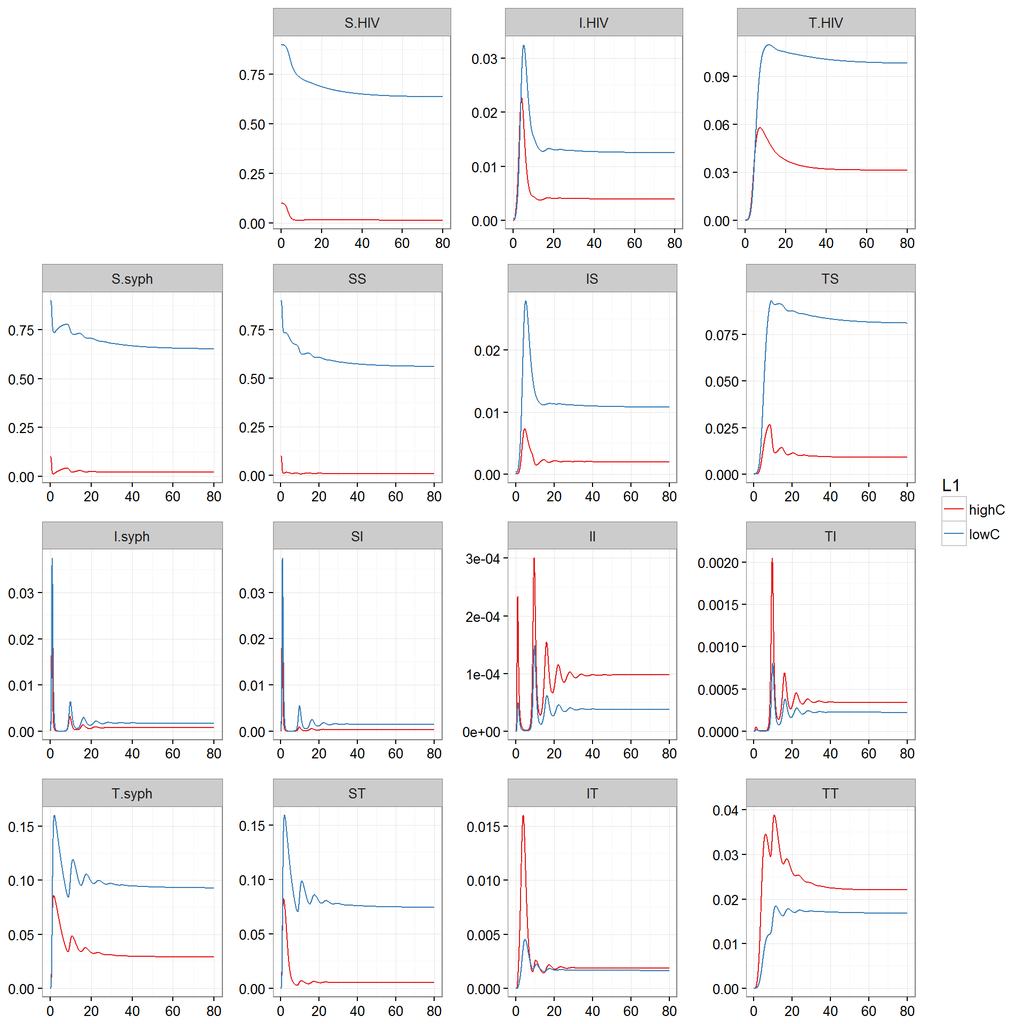

## Total population

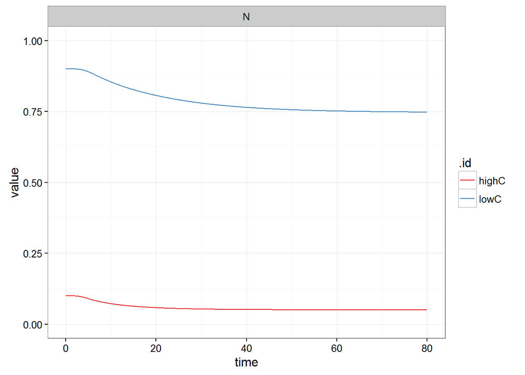

```r
ggplot(subset(sumFrame[["co"]], L1 %in% c("N")), aes(time, value, col = .id)) +
    ylim(0, 1) +
    geom_line() +
    facet_wrap(~L1, scale = "free")
```

## Separate cases

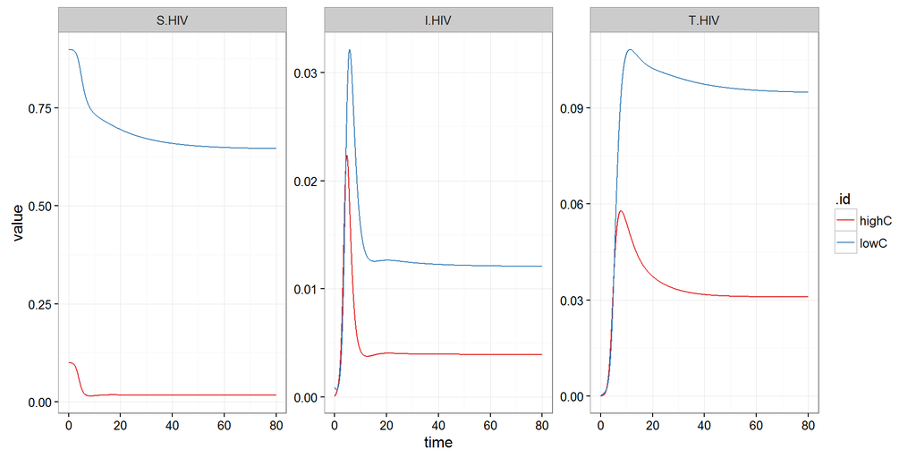

```r
ggplot(sumFrame[["HIV"]], aes(time, value, col = .id)) +
    geom_line() +
    facet_wrap(~L1, scale = "free")
```

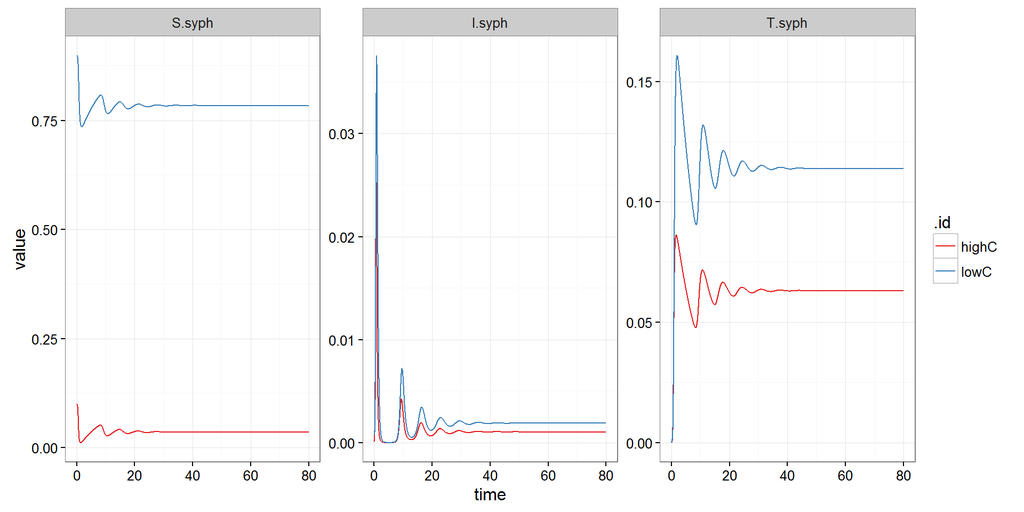

```r
ggplot(sumFrame[["syph"]], aes(time, value, col = .id)) +
    geom_line() +
    facet_wrap(~L1, scale = "free")
```

### Titration

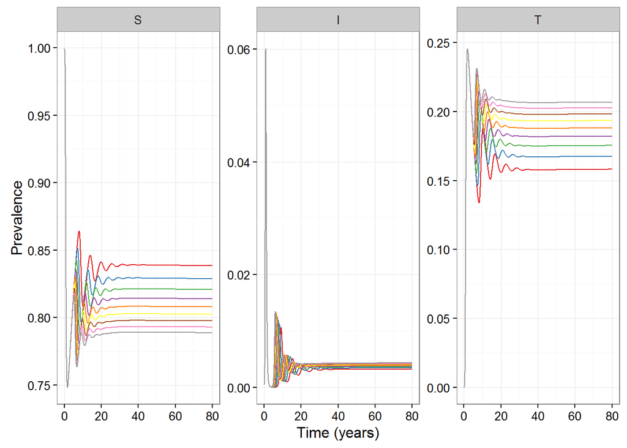

Equilibrium syphilis prevalence from each simulation

```r
print(titrationSyphIPrev[8001,])
```

```
##  [1] 0.003260186 0.003467935 0.003642857 0.003794706 0.003929453
##  [6] 0.004050966 0.004161871 0.004264026 0.004358795 0.004447207
```

36 percent increase in equilibrium prevalence as $\nu_{IS}$ go from 1.1 to 3. Zoomed in plot for syphilis (first 20 years):

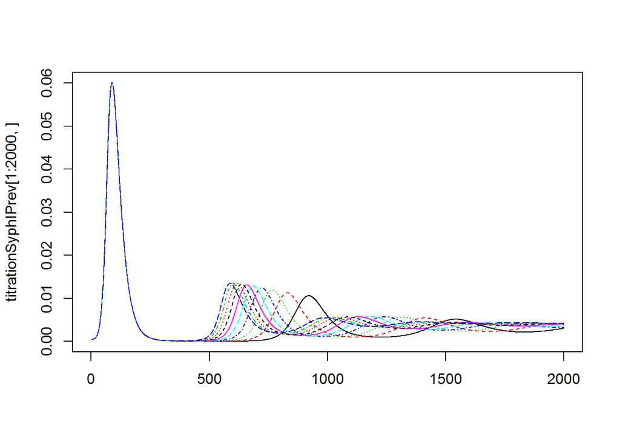

```r
matplot(titrationSyphIPrev[1:2000,], type = "l")
```